# NMsim - Seamless NONMEM Simulation Platform in R

Philip Delff

Simone Cassani

April 11, 2025

# Objectives

This NMsim vignette aims at enabling NONMEM users to modify and run a model directly from within R. This option allows the users to run simulations with parameters modified from theestimated values. The examples described below will address the following pharmacometric questions:

- How is the concentration-time profile affected if switching formulation (reducing absorption rate) by a range of fold-values?
- What is the expected concentration-time profile in patients with a certain Drug-Drug Interaction effect on clearance and bioavailability?
- How will a dose delay of different amounts of time affect the predicted exposure?
- How can AUC computation over a coarse time grid be integrated in the simulation via `NMsim`?

# Variable Parameters

Sometimes we want to simulate with some modification to the estimated model. NMsim canmake such user-specified modifications to the model before simulating through the `modify.model` argument.

Notice, until NMsim 0.1.0, the `modify.model` argument was called `list.sections`. The helper functions `add` and `overwrite` were introduced with NMsim 0.1.3. Until then, custom modification functions had to be provided like described in the section “Edit control stream using customized functions.”

# Configuration

NMsim must be configured with the path to the NONMEM executable. This can be done for each `NMsim()` call using the `path.nonmem` argument, but more easily it can be configured globally the following way. Also including where NMsim will run NONMEM and store intermediate files (`dir.sims`) and where to store final results (`dir.res`).

```r
library(NMdata)
library(NMsim)
## Point NMsim to your NONMEM exectuable - looks like this on linux/osx
NMdataConf(path.nonmem = "/opt/NONMEM/nm75/run/nmfe75")
## or on Windows, it could be
NMdataConf(path.nonmem = "c:/nm75g64/run/nmfe75.bat")
NMdataConf(dir.sims="simtmp-modify", ## location of sim tmp files
           dir.res="simres-modify",
           as.fun="data.table")  ## location of sim results
```

# Change in formulation Example.

The effect on the concentration-time profile of a change in formulation that reduces absorption rate `KA` is explored with the use of a scaling factor `KASCALE=c(1,4,10)` included to the NONMEM control stream via the `modify.model` argument. The absorption rate reduction is provided through the `NMsim` simulation data `dat.sim.varka` containing dosing events, simulation time steps and the value of `KASCALE` for each simulated patient.

First `KASCALE` is added to the simulation data

```r
file.mod <- system.file("examples/nonmem/xgxr021.mod",
                        package="NMsim")
data.sim <- NMreadCsv(system.file("examples/derived/dat_sim1.csv",
                                 package="NMsim"))

#data.sim=setDT(data.sim)
# add KASCALE and copy patient info for each value of KASCALE
dat.sim.varka <- data.sim[,data.table(KASCALE=c(1,4,10)),by=data.sim]
dat.sim.varka[,ID:=.GRP,by=.(KASCALE,ID)] # update patient IDs
setorder(dat.sim.varka,ID,TIME,EVID) # order rows
```

Then the `NMsim` function is used to run the simulation in which the `modify.model` argument is used to simulate a modified model with different absorption rates, scaled by the parameter `KASCALE`. Two different approaches are demonstrated:

1. the effect of the scaling factor `KASCALE` is added at the end of the `PK` section in the NONMEM control stream.

```r
simres.varka <- NMsim(file.mod=file.mod # NONMEM control stream
          ,data=dat.sim.varka # simulation data file
          ,name.sim="varka"
          ,modify.model=list(PK=add("KA=KA/KASCALE")))
```

2. the specific line that defines `TVKA` is modified to include the effect of the scaling factor `KASCALE`

```r
simres.varka2 <- NMsim(file.mod=file.mod
          ,data=dat.sim.varka
          ,name.sim="varka2"
          ,modify.model=list(PK=overwrite("THETA(1)","THETA(1)/KASCALE"))
          )
```

The code below returns the plot

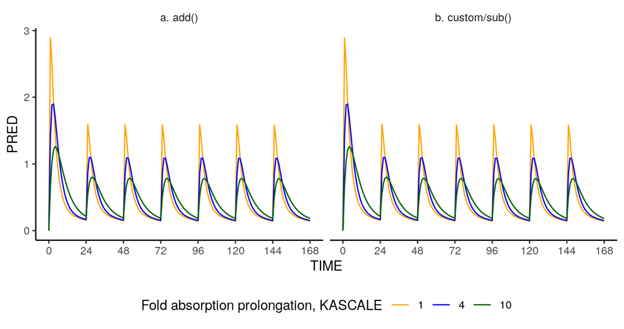

Concentration (`PRED`) profile as a function of time computed by `NMsim` modified models **a** (left) and **b** (right). The equivalence and robustness of the two modified models is supported by the matching results, corresponding to reduced `PRED` values for higher values of `KASCALE` (lower absorption rate).

```r
simres.varka=as.data.table(simres.varka)
simres.varka2=as.data.table(simres.varka2)
simres.both <- rbind(simres.varka[,method:="a. add()"],
                     simres.varka2[,method:="b. custom/sub()"]
                     )

ggplot(simres.both[EVID==2],aes(TIME,PRED,colour=factor(KASCALE)))+
  geom_line()+
  labs(colour="Fold absorption prolongation, KASCALE")+
  scale_x_continuous(breaks=seq(0,168,by=24))+
  facet_wrap(~method)+
  scale_color_manual(values=c("orange", "blue", "darkgreen"))
```

NOTE: the NMsim `overwrite` function prior to version 0.1.6 has a bug that was fixed in the0.1.5.902 github release; it can be installed with

```r
library(remotes)
install_github("NMautoverse/NMsim")
```

# Drug-Drug Interaction (DDI)

The effect of DDI on clearance (`CL`) and bioavailability (`F1`) is simulated for the following scenarios

| scenario | CLSCALE | FSCALE | CLSCALE/FSCALE |
| --- | --- | --- | --- |
| noDDI | 1 | 1 | 1 |
| DDI.1 | 0.5 | 1.2 | 0.42 |
| DDI.2 | 0.33 | 1.1 | 0.3 |

First the `CL` and `F1` data is added to the patient data

```r
## 'Outer join'
dat.sim.DDI=data.sim[,data.table(CLSCALE=c(1,1/2,1/3)
                                ,FSCALE=c(1,1.2,1.1)
                                ,lab=c("noDDI","DDI.1","DDI.2"))
                    ,by=data.sim]
dat.sim.DDI[,ID:=.GRP,by=.(lab,ID)]
setorder(dat.sim.DDI,ID,TIME,EVID)
```

Then, the DDI driven change in parameters is added at the end of the PK section of the NONMEM control stream via the `modify.model` argument in the `NMsim()` function.

```r
simres.DDI <- NMsim(file.mod=file.mod
            ,data=dat.sim.DDI
            ,name.sim="DDI"
            ,modify.model=list(PK=add("CL=CL*CLSCALE"
                                      ,"F1=FSCALE")))
```

The effect on the concentration-time profile is shown in the figure below

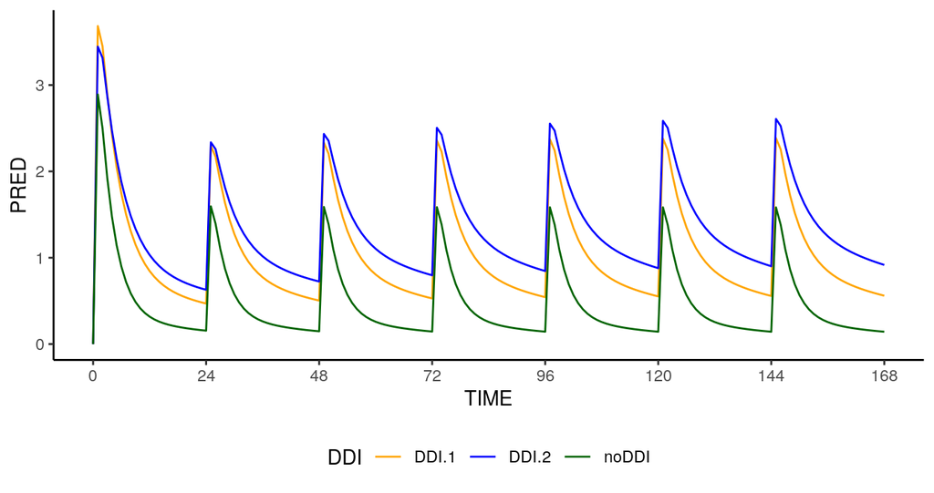

Concentration (`PRED`) profile as a function of time computed by `NMsim` modified model for different DDIs. The modified model correctly simulates (i) a higher value of `Cmax` on day 1 for higher biovalability; (ii) a higher `PRED` value at steady state for lower apparent clearance effect `CLSCALE/FSCALE` values.

# Dose delay

Deviations in the administration schedule of a drug are simulated including three parameters in the dataset: the dose number `DOSCUMN`, obtained with `NMdata::addTAPD()`, the specific number of the delayed dose `DELAYDOS` and the time delay `ALAG`.

```r
dat.sim.alag = data.sim |> NMexpandDoses() |> addTAPD() # expand doses and add dose number
dat.sim.alag[,ROW:=.I] # restore ROW with correct value
# add delayed dose
dat.sim.dos.delay=dat.sim.alag[,data.table(DELAYDOS=c(2,3,4,5,6,7))
                                ,by=dat.sim.alag]
# add dose delay
dat.sim.alag.final=dat.sim.dos.delay[,data.table(ALAG=c(0,6,12,18,24))
                                     ,by=dat.sim.dos.delay]
# update ID
dat.sim.alag.final[,ID:=.GRP,by=.(ALAG,DELAYDOS,ID)]
setorder(dat.sim.alag.final,ID,TIME,EVID)
#dat.sim.alag.final = dat.sim.alag.final |> fill(DOSCUMN)
```

The following patient has a 6 hours delay to the administration of dose 2.

| TIME | AMT | DOSCUMN | DELAYDOS | ALAG |
| --- | --- | --- | --- | --- |
| 0 | 300 | 1 | 2 | 6 |
| 24 | 150 | 2 | 2 | 6 |
| 48 | 150 | 3 | 2 | 6 |
| 72 | 150 | 4 | 2 | 6 |
| 96 | 150 | 5 | 2 | 6 |
| 120 | 150 | 6 | 2 | 6 |
| 144 | 150 | 7 | 2 | 6 |

The time delay is included in the modified control stream with `NMsim` adding a single line at the end of the PK section, where the dose delay on compartment 1 `ALAG1` is modified for the dose with dose number `DOSCUMN` equal to the target delayed dose number `DELAYDOS`

```r
simres.alag <- NMsim(file.mod=file.mod
              ,data=dat.sim.alag.final
              ,name.sim="alag"
              ,modify.model=list(PK=
                    add("IF(DOSCUMN.EQ.DELAYDOS) ALAG1=ALAG")))
```

The effect on concentration-time profiles and daily AUC are shown in the two images below.

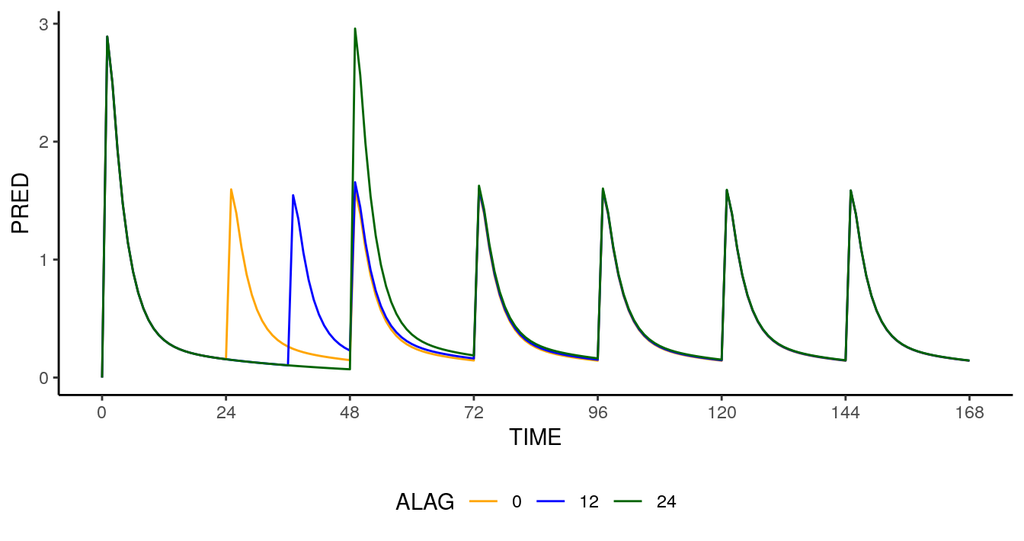

Effect of time delay (0, 12 and 24 hours on dose 2) on concentration (`PRED`) profile as a function of time computed by `NMsim` modified model. The implementation of the modified model simply consists of the addition of the variables `DOSCUMN`, `DELAYDOS`, and `ALAG` to the original data set, and the addition of one line of code to the PK section of the control stream via `modify.model`.

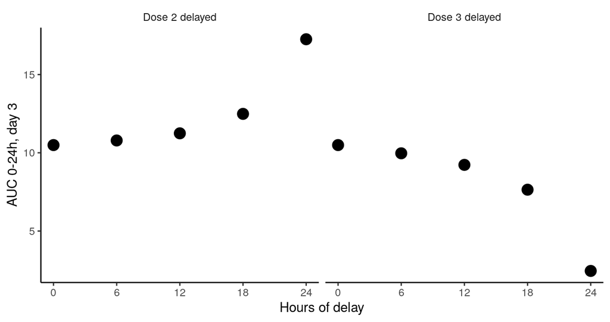

Daily exposure on day 3 as a function of time delay for dose 2 (left) and dose 3 (right). The simulation results predict an increased risk for possible safety concerns (left panel, over-exposure) and loss of efficacy (right panel, under-exposure) as dose time delay gets larger.

# AUC

The following example computes daily exposure:

- at post-processing, using trapezoidal method, after the unmodified NONMEM model is simulated on three different fine grids with evenly spaced time steps of `0.25`, `1`, and `4` hours, respectively, labelled **AUC trapz**

```r
file.mod.auc <- system.file("examples/nonmem/xgxr046.mod",
                        package="NMsim")
data.sim.auc <- NMreadCsv(system.file("examples/derived/dat_sim1.csv",
                                 package="NMsim"))
data.sim.auc[,AMT:=1000*AMT]

# time step 1hr
data.sim.1hr=data.sim.auc
data.sim.1hr[,TSTEP:="1hr"]

# time step 0.25hr
data.sim.0.25hr=addEVID2(data.sim.auc[EVID==1],CMT=2,time.sim=seq(0,192,by=0.25))
data.sim.0.25hr[,TSTEP:="0.25hr"]

# time step 4hr
data.sim.4hr <- addEVID2(data.sim.auc[EVID==1],CMT=2,time.sim=seq(0,192,by=4))
data.sim.4hr[,TSTEP:="4hr"]

sres.trapz <- NMsim(file.mod=file.mod.auc
      ,data=list(data.sim.1hr # run NMsim on a list of data sets to run all different scenarios at once
                 ,data.sim.0.25hr
                 ,data.sim.4hr)
      ,seed=12345
      ,table.vars=cc(PRED,IPRED)
      ,name.sim="AUC.trapz"
      ,reuse.results=reuse.results
      )
```

[output not shown]

```r
# daily AUC computation
sim.auc=sres.trapz[EVID==2,.(ID,TIME,PRED,time.step=TSTEP)]
sim.auc[,DAY:=(TIME%/%24)+1] # define DAY variable
# create duplicate time steps for end-of-day
# (e.g 24h belongs to both day 1 and day2)
sim.dupli.24h=sim.auc[TIME%%24==0 & TIME>0,.(ID
                                             ,DAY=DAY-1
                                             ,TIME
                                             ,PRED
                                             ,time.step)]
sim.auc.final <- rbind(sim.auc
                       ,sim.dupli.24h) |> setorder(ID,DAY,TIME,time.step)

sim.auc.trapz<-sim.auc.final[DAY<8,.(AUC=pracma::trapz(TIME,PRED))
                             ,by=.(ID,DAY,time.step)]
# stmp=sres1[EVID==2,.(ID,TIME,PRED)]
# stmp[,DAY:=(TIME%/%24)+1]
# sAUC<-stmp[,.(AUC=pracma::trapz(TIME,PRED)),by=.(ID,DAY)]
```

- at run time, with an `NMsim` modified script, on a course grid with evenly spaced time steps of `24` hours, labelled **AUC $DES**. Of note, this task requires additions to the control stream in multiple sections.

```r
# AUC with NMsim -  time step 24hr
data.sim2 <- addEVID2(data.sim.auc[EVID==1],CMT=2,time.sim=seq(0,by=24,length.out=9))

sres.des <- NMsim(file.mod=file.mod.auc
          ,data=data.sim2
          ,table.vars=cc(PRED,IPRED,AUCNMSIM)
          ,name.sim="AUC.nmsim"
          ,seed=12345
          ,reuse.results=reuse.results
          ,modify.model=list(MODEL=add("COMP=(AUC)")
                  ,DES=add("DADT(3)=A(2)/V2")
                  ,ERROR=add("AUCCUM=A(3)"
                             ,"IF(NEWIND.NE.2) OLDAUCCUM=0"
                             ,"AUCNMSIM = AUCCUM-OLDAUCCUM"
                             ,"OLDAUCCUM = AUCCUM")))

sres.des[,DAY:=TIME%/%24]
sres.des[,AUC.NMsim:=AUCNMSIM]
sres.auc.des=sres.des[AUCNMSIM!=0,.(TIME,DAY,PRED,AUC.NMsim)]
```

The plot comparing the `DES` and `trapz` AUC is obtained with the code below

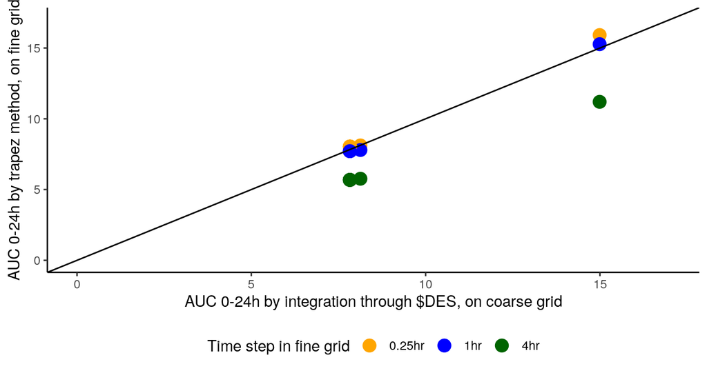

```r
sres.final=mergeCheck(sim.auc.trapz[,.(DAY,AUC,time.step)]
                      ,sres.auc.des[,.(DAY,AUC.NMsim)]
                      ,by="DAY")

ggplot(data=sres.final,aes(AUC.NMsim,AUC,colour=factor(time.step)))+
  geom_point(size=4)+
  labs(colour="Time step in fine grid")+
  scale_color_manual(values=c("orange", "blue", "darkgreen"))+
  xlim(c(0,17))+
  ylim(c(0,17))+
  ylab("AUC 0-24h by trapez method, on fine grid")+
  xlab("AUC 0-24h by integration through $DES, on coarse grid")+
  geom_abline(slope=1, intercept=0)
```